# Used Car Price Evaluation Project

```python
import os
import json
import sys
import pandas as pd
import seaborn
import numpy
from tqdm import tqdm
import matplotlib.pyplot as plt
import sklearn
from sklearn.metrics import r2_score
```

```python
with open('Data/car_data.json','r') as f:
    car_data=json.load(f)
    f.close()
with open('Data/key_pos.csv','r')as f :
    key_pos=pd.read_csv(f)
    f.close()
with open('Data/key_vin.csv','r') as f:
    key_vin=pd.read_csv(f)
    f.close()
```

## Data Cleaning & Transformation

This step transforms the json format data into panda dataframe with selected attributes. Some values in the column are transformed into appropriate data type or format (e.g., change price[str] into price[int]). I extracted [year,make,model] from the attribute title by splitting the string. Some NA values are removed and filled by mode.

```python
rows=[]
for i in tqdm(car_data):
    row={}
    row['ID']=i
    for k,v in car_data[i]['vehicle_head_info'].items():
        row[k]=v
    for k,v in car_data[i]['seller_info'].items():
        row[k]=v
    for k,v in car_data[i]['basics'].items():
        row[k]=v
    row['features']=len(car_data[i]['all_features'])
    rows.append(row)
```

```python
#define some functions for mapping
#might be a bit tedious but I personally prefer writing functions
def to_int(x):
    if isinstance(x, str):
        x=x.replace('$','')
        x=x.replace(',','')
        x=int(x)
    else:
        x=x
    return x

def to_flt(x):
    if isinstance(x, str):
        try:
            x=float(x)
        except:
            x=4.0
    else:
        x=float(x)
    return x
def review(x):
    if isinstance(x, str):
        x=int(x.replace(' Reviews',''))
    return x

def odor(x):
    if isinstance(x, str):
        x=x.replace('miles','').replace(',','')
        x=int(x)
    return x
def year(x):
    year=[int(s) for s in x.split() if s.isdigit()][0]
    return year
def brand(x):
    brand=[s for s in x.replace('Certified','').split() if not s.isdigit()][0]
    return brand
def model(x):
    model=x.replace('Certified','')
    try:
        model=model.split()[2]
    except:
        model=model[5:]
    return model
def city(x):
    if isinstance(x,str):
        x=x.split(',')[0]
    else:
        x='unknown'
    return x
def state(x):
    if isinstance(x,str):
        x=x.split(',')[1][0:2]
    else:
        x='CA'
    return x
```

```python
#replace missing value in seller_reviews_count with 0, missing ratings will be 4.0
car = pd.DataFrame(rows)
car.fillna(car.mode(),inplace = True)

car['seller_rating']=car['seller_rateing'].apply(to_flt).fillna(4.0)
car['seller_reviews_count']=car['seller_reviews_count'].apply(review)
car['Mileage']=car['odometer'].apply(odor)
car['year']=car['title'].apply(year)
car['make']=car['title'].apply(brand)
car['model']=car['title'].apply(model)
car['price']=car['price'].apply(to_int).dropna()
car['seller_city']=car['seller_position'].apply(city)
car['seller_state']=car['seller_position'].apply(state)
car['seller_reviews_count']=car['seller_reviews_count'].fillna(0)

car=car.drop(columns=['Trim', 'seller_rateing','seller_notes','odometer','seller_position'])
car=car.dropna(subset=['price','Mileage'])
```

### Car_data.json after transforamtion looks like a panda dataframe below

Since we will be diving into predicting car price, I dropped all rows that don't hava a valid price.

```python
car.info()
```

```
<class 'pandas.core.frame.DataFrame'>
Int64Index: 29553 entries, 0 to 30624
Data columns (total 23 columns):
 #   Column                Non-Null Count  Dtype
---  ------                --------------  -----
 0   ID                    29553 non-null  object
 1   title                 29553 non-null  object
 2   price                 29553 non-null  float64
 3   seller_name           29550 non-null  object
 4   seller_reviews_count  29553 non-null  float64
 5   Fuel Type             29553 non-null  object
 6   Exterior Color        29190 non-null  object
 7   City MPG              26262 non-null  object
 8   Interior Color        25883 non-null  object
 9   Highway MPG           26246 non-null  object
 10  Stock                 29550 non-null  object
 11  Drivetrain            27318 non-null  object
 12  Transmission          28829 non-null  object
 13  Engine                28250 non-null  object
 14  VIN                   29551 non-null  object
 15  Mileage               29553 non-null  float64
 16  features              29553 non-null  int64
 17  seller_rating         29553 non-null  float64
 18  year                  29553 non-null  int64
 19  make                  29553 non-null  object
 20  model                 29553 non-null  object
 21  seller_city           29553 non-null  object
 22  seller_state          29553 non-null  object
dtypes: float64(4), int64(2), object(17)
memory usage: 5.4+ MB
```

## Exploratory Analysis

```python
car.isnull().sum()
```

```
ID                         0
title                      0
price                      0
seller_name                3
seller_reviews_count       0
Fuel Type                  0
Exterior Color           363
City MPG                3291
Interior Color          3670
Highway MPG             3307
Stock                      3
Drivetrain              2235
Transmission             724
Engine                  1303
VIN                        2
Mileage                    0
features                   0
seller_rating              0
year                       0
make                       0
model                      0
seller_city                0
seller_state               0
dtype: int64
```

## Visualizations

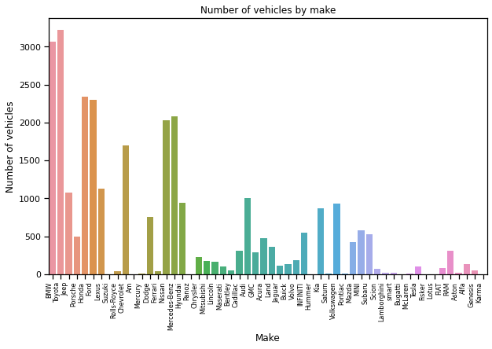

```python
plt.figure(figsize=(10,6))
ax = sns.countplot(x='make',data=car);
ax.set_xticklabels(ax.get_xticklabels(), rotation=90, ha="right",fontsize=8);
plt.title("Manufacturers vs no. of listings")
plt.title("Number of vehicles by make")
plt.ylabel('Number of vehicles')
plt.xlabel('Make');
```

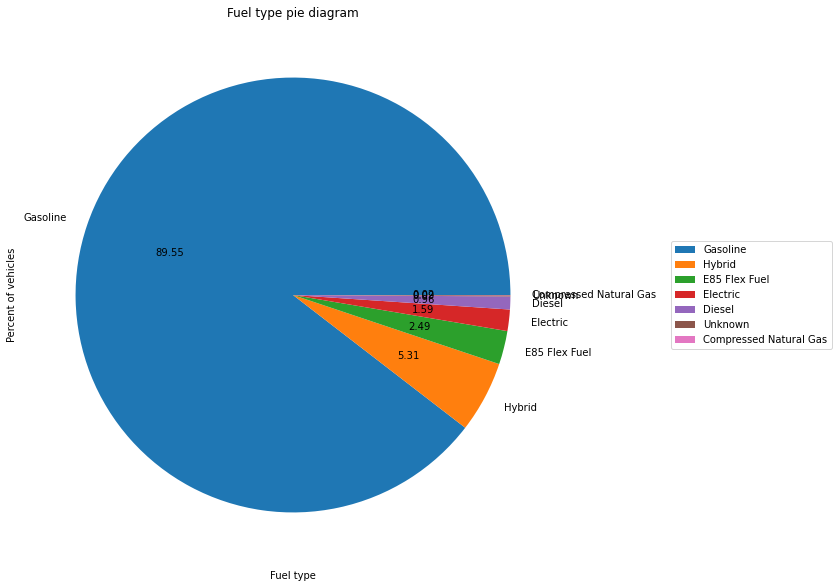

```python
car['Fuel Type'].value_counts().plot.pie(figsize=(10, 10), autopct='%.2f')
plt.title("Fuel type pie diagram")
plt.ylabel('Percent of vehicles')
plt.xlabel('Fuel type')

plt.legend(loc="center right",bbox_to_anchor=(1, 0, 0.5, 1))
```

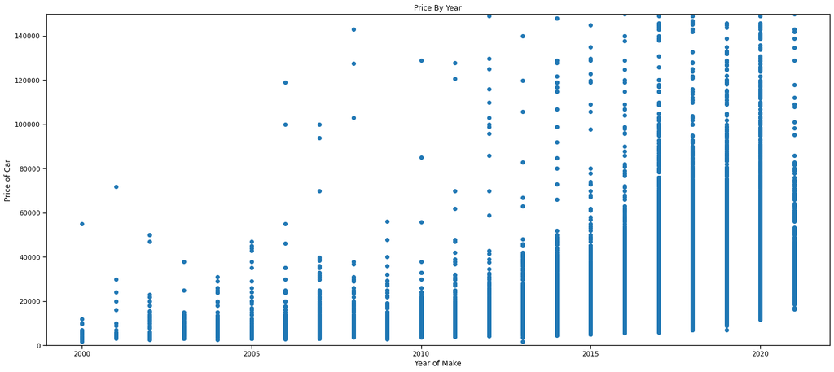

```python
plt.rcParams['figure.figsize']=(23,10)
plt.scatter(y='price',x="year", data=car)
plt.ylim(0,150000)
plt.title("Price By Year")
plt.ylabel('Price of Car')
plt.xlabel('Year of Make')
```

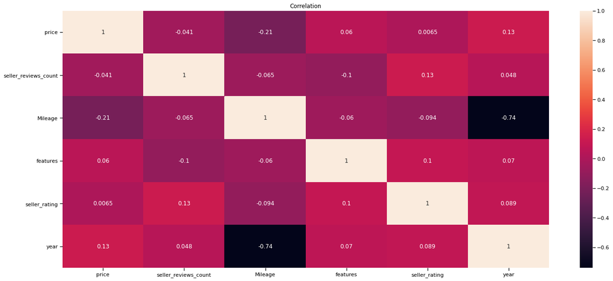

```python
sns.heatmap(car.corr(), annot = True)
plt.title("Correlation")
plt.show()
```

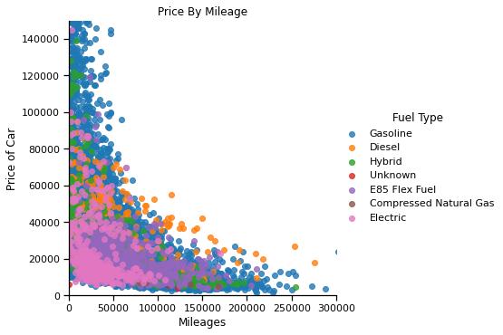

```python
g = sns.lmplot(x='Mileage',y="price",data= car, hue="Fuel Type", fit_reg=False)
plt.xlim(0,300000)
plt.ylim(0,150000)
plt.title("Price By Mileage")
plt.ylabel('Price of Car')
plt.xlabel('Mileages')
```

## Prediction Models

I selected a few features that seem to have a bit more correlation with price to include in the training of prediction models.

Test set is 25% of whole set, and train set is 75% of whole set.

```python
car_features=car[["price","seller_city","year","Mileage",'features','Fuel Type','Highway MPG','make']].dropna()
car_features['Highway MPG']=car_features['Highway MPG'].apply(lambda x: int(x))
scaler = MinMaxScaler()
num_vars=['price','year','Mileage','features','Highway MPG']
car_features['year_use']=2021-car_features['year']
#car_features[num_vars] = scaler.fit_transform(car_features[num_vars])
car_features.info()
```

```
<class 'pandas.core.frame.DataFrame'>
Int64Index: 26246 entries, 0 to 30624
Data columns (total 9 columns):
 #   Column       Non-Null Count  Dtype
---  ------       --------------  -----
 0   price        26246 non-null  float64
 1   seller_city  26246 non-null  object
 2   year         26246 non-null  int64
 3   Mileage      26246 non-null  float64
 4   features     26246 non-null  int64
 5   Fuel Type    26246 non-null  object
 6   Highway MPG  26246 non-null  int64
 7   make         26246 non-null  object
 8   year_use     26246 non-null  int64
dtypes: float64(2), int64(4), object(3)
memory usage: 2.0+ MB
```

```python
from sklearn.model_selection import train_test_split
from sklearn.linear_model import LinearRegression
from sklearn.preprocessing import MinMaxScaler
from sklearn import linear_model

from sklearn.feature_selection import RFE

import statsmodels.api as sm
from statsmodels.stats.outliers_influence import variance_inflation_factor
```

```python
train, test= train_test_split(car_features,test_size=0.25, random_state=0)

train.head(5)

print('Training set length:',len(train),'Testing set length:',len(test))
```

```
Training set length: 19684 Testing set length: 6562
```

### Linear Regression Model

The R-squared is just 0.319, and the model doesn't do well when it comes to newer vehicles.

```
                                 OLS Regression Results
=======================================================================================
Dep. Variable:                  price   R-squared (uncentered):                   0.319
Model:                            OLS   Adj. R-squared (uncentered):              0.319
Method:                 Least Squares   F-statistic:                              2305.
Date:                Sat, 24 Apr 2021   Prob (F-statistic):                        0.00
Time:                        22:45:55   Log-Likelihood:                     -2.3638e+05
No. Observations:               19684   AIC:                                  4.728e+05
Df Residuals:                   19680   BIC:                                  4.728e+05
Df Model:                           4
Covariance Type:            nonrobust
===============================================================================
                  coef    std err          t      P>|t|      [0.025      0.975]
-------------------------------------------------------------------------------
year_use     1721.9008    141.139     12.200      0.000    1445.256    1998.546
Mileage        -0.2852      0.013    -22.115      0.000      -0.310      -0.260
features      248.0459      4.500     55.123      0.000     239.226     256.866
Highway MPG   105.6278      9.816     10.761      0.000      86.388     124.868
==============================================================================
Omnibus:                    59009.971   Durbin-Watson:                   2.007
Prob(Omnibus):                  0.000   Jarque-Bera (JB):       6944062588.748
Skew:                          43.576   Prob(JB):                         0.00
Kurtosis:                    2911.445   Cond. No.                     2.67e+04
==============================================================================

Notes:
[1] R² is computed without centering (uncentered) since the model does not contain a constant.
[2] Standard Errors assume that the covariance matrix of the errors is correctly specified.
[3] The condition number is large, 2.67e+04. This might indicate that there are
strong multicollinearity or other numerical problems.
```

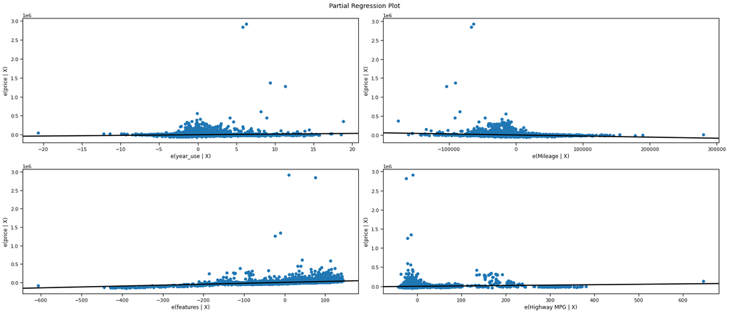

```python
X=train[['year_use','Mileage','features','Highway MPG']]
X_test=test[['year_use','Mileage','features','Highway MPG']]
y=train['price']
lm=sm.OLS(y,X).fit()
print(lm.summary())
fig = sm.graphics.plot_partregress_grid(lm)
fig.tight_layout(pad=1.0)
```

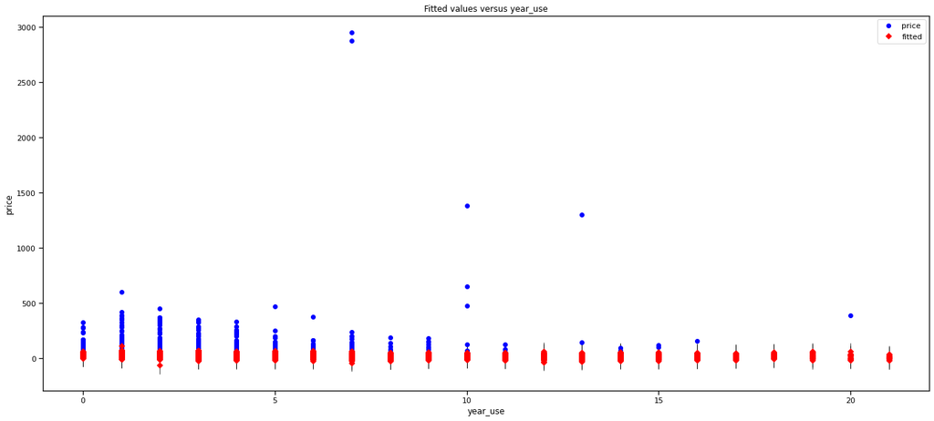

```python
fig, ax = plt.subplots()
fig = sm.graphics.plot_fit(lm, 0, ax=ax)
```

```
(0.0, 120000.0)
```

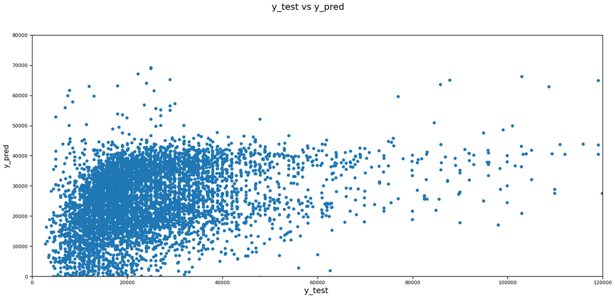

```python
y_pred = lm.predict(X_test)
y_test=test['price']

fig = plt.figure()
plt.scatter(y_test,y_pred)
fig.suptitle('y_test vs y_pred', fontsize=20)
plt.xlabel('y_test ', fontsize=18)
plt.ylabel('y_pred', fontsize=16)
plt.ylim(0,80000)
plt.xlim(0,120000)
```

```
                            OLS Regression Results
==============================================================================
Dep. Variable:                  price   R-squared:                       0.089
Model:                            OLS   Adj. R-squared:                  0.089
Method:                 Least Squares   F-statistic:                     138.0
Date:                Sat, 24 Apr 2021   Prob (F-statistic):               0.00
Time:                        23:02:34   Log-Likelihood:            -2.3581e+05
No. Observations:               19684   AIC:                         4.717e+05
Df Residuals:                   19669   BIC:                         4.718e+05
Df Model:                          14
Covariance Type:            nonrobust
==============================================================================
                 coef    std err          t      P>|t|      [0.025      0.975]
------------------------------------------------------------------------------
const       4.321e+04   2977.032     14.514      0.000    3.74e+04     4.9e+04
x1          2306.3469    658.612      3.502      0.000    1015.412    3597.281
x2            -0.4312      0.061     -7.093      0.000      -0.550      -0.312
x3          -128.9668     39.361     -3.277      0.001    -206.117     -51.816
x4          -331.2634     55.415     -5.978      0.000    -439.882    -222.645
x5           104.1684     26.918      3.870      0.000      51.406     156.931
x6            -0.0500      0.004    -12.274      0.000      -0.058      -0.042
x7             8.6196      4.784      1.802      0.072      -0.758      17.998
x8            -8.6651      4.593     -1.887      0.059     -17.667       0.337
x9          4.704e-06   2.44e-07     19.285      0.000    4.23e-06    5.18e-06
x10           -0.0020      0.000     -4.583      0.000      -0.003      -0.001
x11           -0.0008      0.000     -1.917      0.055      -0.002     1.8e-05
x12            1.0669      0.171      6.249      0.000       0.732       1.402
x13            1.5509      0.371      4.179      0.000       0.823       2.278
x14            0.8308      0.085      9.806      0.000       0.665       0.997
==============================================================================
Omnibus:                    60133.014   Durbin-Watson:                   2.011
Prob(Omnibus):                  0.000   Jarque-Bera (JB):       8080555171.469
Skew:                          45.916   Prob(JB):                         0.00
Kurtosis:                    3140.499   Cond. No.                     6.08e+10
==============================================================================

Notes:
[1] Standard Errors assume that the covariance matrix of the errors is correctly specified.
[2] The condition number is large, 6.08e+10. This might indicate that there are
strong multicollinearity or other numerical problems.
```

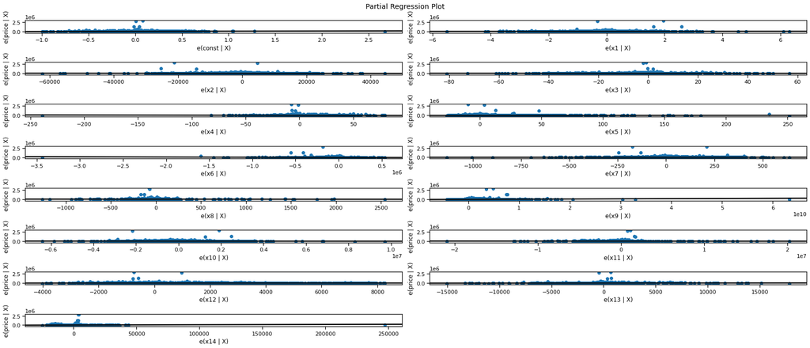

```python
from sklearn.preprocessing import PolynomialFeatures
pf=PolynomialFeatures(degree=2)
xp=pf.fit_transform(X)
pm=sm.OLS(y,xp).fit()
pmpred=pm.predict(xp)
print(pm.summary())
fig = sm.graphics.plot_partregress_grid(pm)
fig.tight_layout(pad=1.0)
```

## Random Forest Tree

```python
X=car_features
y=car_features['price']
from sklearn.preprocessing import scale
# subset all categorical variables
cars_categorical = X.select_dtypes(include=['object'])
# convert into dummies
cars_dummies = pd.get_dummies(cars_categorical, drop_first=True)
# drop categorical variables
X = X.drop(list(cars_categorical.columns), axis=1)
# concat dummy variables with X
X = pd.concat([X, cars_dummies], axis=1)
cols = X.columns
X = pd.DataFrame(scale(X))
X.columns = cols
y=y.reset_index()['price']
```

```python
from sklearn.ensemble import RandomForestRegressor
```

```python
train_features, test_features, train_labels, test_labels = train_test_split(X,y, test_size = 0.25, random_state = 42)

rf = RandomForestRegressor(n_estimators = 800, random_state = 42)
# Train the model on training data
rf.fit(train_features, train_labels)
```

```
RandomForestRegressor(n_estimators=800, random_state=42)
```

```python
predictions = rf.predict(test_features)
# Calculate the absolute errors
errors = abs(predictions - test_labels)
numpy.mean(errors)
```

```
53.53235198872312
```

```python
import numpy as np
mape = 100 * (errors / test_labels)
# Calculate and display accuracy
accuracy = 100 - np.mean(mape)
print('Accuracy:', round(accuracy, 2), '%.')
```

```
Accuracy: 99.98 %.
```

```python
from sklearn.tree import export_graphviz
feature_list = list(X.columns)
# Pull out one tree from the forest
tree = rf.estimators_[5]
# Import tools needed for visualization
from sklearn.tree import export_graphviz

# Pull out one tree from the forest
tree = rf.estimators_[5]
# Export the image to a dot file
export_graphviz(tree, out_file = 'tree.dot',feature_names = feature_list, rounded = True, precision = 1)
```

```python
rf_small = RandomForestRegressor(n_estimators=10, max_depth = 3)
rf_small.fit(train_features, train_labels)
# Extract the small tree
tree_small = rf_small.estimators_[5]
# Save the tree as a png image
export_graphviz(tree_small, out_file = 'small_tree.dot', feature_names = feature_list, rounded = True, precision = 1)
```

## A part of tree looks like this

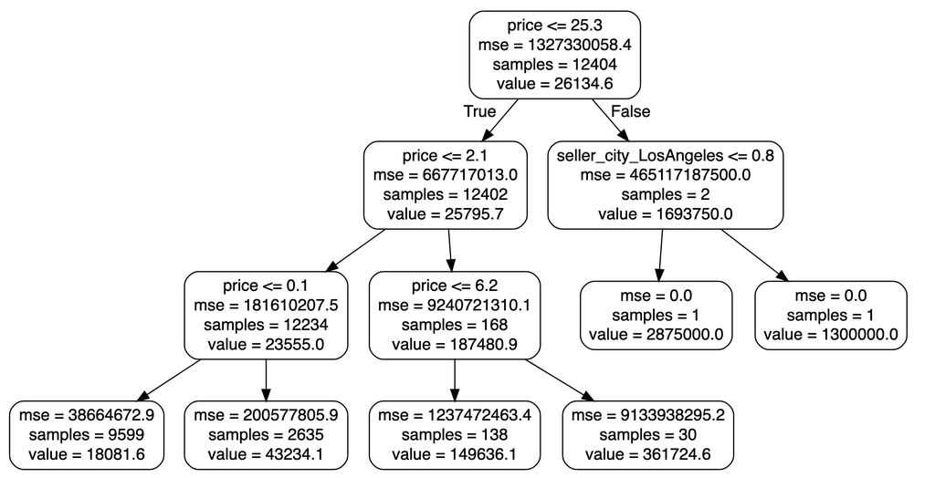

```python
from IPython.display import Image
Image(filename='tree.png')
```